# Modelos geoestadísticos y procesos espaciales.

Modelo Espacial autoregresivo (SAR)

Nelson Alirio Cruz

nelsonaliriocruz@gmail.com

Universidad Nacional de Colombia

# Bloque 1: Clase para pregrado

## Introducción a la autocorrelación

Concepto: la autocorrelación refleja que valores cercanos espacial o temporalmente tienden a ser similares.

- Temporal: precios de acciones, temperatura diaria,
- Espacial: deforestación, crimen por vecindario.

```r
DataCovariates <- read_excel("DataCovariates.xlsx")
gini <- read_excel("Distribution.xlsx")
DataTotal <-merge(gini, y=DataCovariates,
                        by.x="CODMUNI", by.y="Divipola", all.x=TRUE, all.y = TRUE)

mapColombia <-read_sf("Shape/Municipios_desercion.shp", , options = "ENCODING=UTF8") # 380 units

DataTotal <- merge(x=mapColombia, y=DataTotal,
                    by.x="mpio_cdpmp", by.y="CODMUNI", all.x=TRUE)
```

## Índice de Gini en Colombia

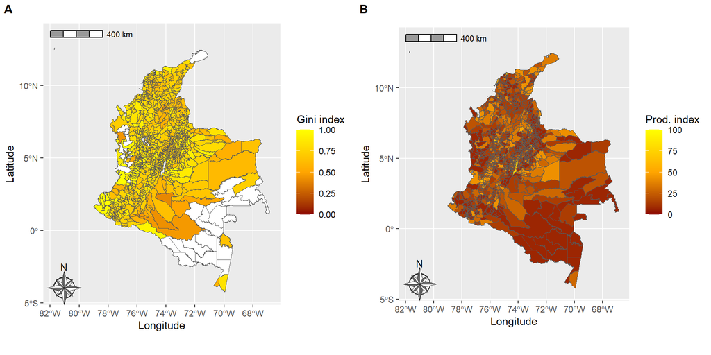

## Autoregresión temporal vs espacial

| Aspecto | AR temporal | AR espacial |
| --- | --- | --- |
| Variable dependiente | $y_t$ | $y_i$ |
| Dependencia | Tiempos anteriores: $y_{t-1}, \ldots, y_{1}$ | Vecinos $y_1, \ldots, y_{i-1}, y_{i+1}, \ldots, y_n$ |
| Fórmula básica | $y_t = \sum_{j=1}^p \phi_j y_{t-j} + \epsilon_t$ | $y_i = \rho\sum_{j=1}^n w_{ij}\times y_j + \epsilon_j$ |
| Interpretación | Persistencia temporal | Dependencia entre ubicaciones |
| Parámetros estructurales | Elección de $p$ | Elección de $w_{ij}$ |

## Matriz de pesos $\mathbf{W}$

$$\mathbf{W}=\begin{pmatrix}
0 & w_{12} & w_{13} & \cdots &w_{1n}\\
w_{21} & 0 & w_{23} & \cdots &w_{2n}\\
w_{31} & w_{32} & 0 &\cdots &w_{3n}\\
\vdots& \vdots & \vdots & \ddots &\vdots\\
w_{n1} & w_{n2} & w_{n3} & \cdots &0\\
\end{pmatrix}$$

**Vecinos**

Define qué observaciones son “vecinas”. Algunos ejemplos pueden ser:

- Binaria: \(w_{ij} = 1\) si \(i\) y \(j\) son vecinos
- Inversa a distancia: \(w_{ij} = 1/d_{ij}\)

Normalización: $\sum_{i=1}^n w_{ij}=1$ facilita interpretación de \(\rho\)

## Modelo SAR básico

$$\mathbf{y} = \rho \pmb{W} \mathbf{y} + \mathbf{X}\boldsymbol{\beta} +\boldsymbol{\epsilon}$$

Donde $\mathbf{y}$ es el vector $n \times 1$ de las variables dependientes de interés, $\mathbf{X}$ es una matriz $n \times k$ de variables explicativas con coeficientes asociados $\boldsymbol{\beta}$

**Es un modelo lineal “clásico”**

$$\mathbf{y}-\rho \pmb{W} \mathbf{y} = \mathbf{X}\boldsymbol{\beta} +\boldsymbol{\epsilon}$$

$$\mathbf{Ay} = \mathbf{X}\boldsymbol{\beta} +\boldsymbol{\epsilon}$$

$$\mathbf{y} = \mathbf{A}^{-1}\mathbf{X}\boldsymbol{\beta} +\mathbf{A}^{-1}\boldsymbol{\epsilon}$$

**Tarea**

Demuestra que si $\vert \rho \vert<1$ entonces $\mathbf{A}^{-1}=\sum_{j=0}^\infty \rho^j\mathbf{W}^j$

## Estimación

Para obtener la función de verosimilitud:

- La varianza de $\mathbf{y}=\sigma^2\mathbf{A}^{-1}(\mathbf{A}^{-1})^\top$
- El termino $\pmb{\epsilon}= \mathbf{Ay} - \mathbf{X}\boldsymbol{\beta}$ nos permite construir la verosimilitud.

  $$L(\pmb{\beta}, \rho, \sigma^2)=(2\pi)^{-\frac{n}{2}}\vert \mathbf{A}\vert\exp\left(-\frac{1}{2}\pmb{\epsilon}^\top\pmb{\epsilon} \right)$$

  $$\ell(\pmb{\beta}, \rho, \sigma^2)=-\frac{n}{2}\ln(2\pi)+\ln\vert \mathbf{A}\vert-\frac{1}{2}\pmb{\epsilon}^\top\pmb{\epsilon}$$

  $$\frac{\partial{\ell}}{\partial\boldsymbol{\beta}}=\pmb{\epsilon}^{\top}\mathbf{X}, \; \frac{\partial{\ell}}{\partial\rho}=-\mbox{tr} (\mathbf{A}^{-1} \mathbf{W})+\pmb{\epsilon}^{\top}\mathbf{W} \mathbf{y}$$

## Estimación

**OLS**

$\hat{\pmb{\beta}}$ es un estimador de mínimos cuadrados “ordinarios” si $\rho$ es conocido.

$$\hat{\boldsymbol{\beta}}=\left(\mathbf{X}^{\top}\mathbf{X}\right)^{-1}\mathbf{X}^{\top}\mathbf{A}\mathbf{y}$$

**$\rho$**

Para estimar $\rho$ no se tiene una solución exacta, pero se puede obtar por dos metodos:

1. Scoring Fisher: $\mathcal{I}_{{\rho}{\rho}}=\text{tr}(\mathbf{A}^{-1}\mathbf{W})^2+\text{tr}(\mathbf{W}\mathbf{A} ^{-1})^\top(\mathbf{W}\mathbf{A}^{-1})+(\mathbf{W}\mathbf{A}^{-1}\mathbf{X}\boldsymbol{\beta})(\mathbf{W}\mathbf{A}^{-1}\mathbf{X}\boldsymbol{\beta})$
2. Máximización directa $\hat{\rho}=\mbox{argmax}_{\rho\in(-1,1)}\left(\ln\vert \mathbf{A}\vert-\frac{1}{2}\pmb{\epsilon}^\top\pmb{\epsilon}\right)$

**Tarea**

Demuestra $\mathcal{I}_{{\rho}{\rho}}$ está bien calculada, además que es positiva.

## Propiedades de los estimadores

**MLE**

- Los estimadores obtenidos por máxima verosimilitud son asintoticamente insesgados, consistentes y normales su los supuestos son ciertos(*Theory of Point Estimation* 1998). (Bivand, Millo, y Piras 2021a)
- Sí el supuesto de normalidad no se cumple, (Lee 2004) demuestra que aún siguen siendo normales, pero su varianza asintotica cambia.
- Sí el supuesto de homocedasticidad no se cumple, (Kelejian y Prucha 2010) encuentra un estimador robusto con mejor desempeño que el OLS usual. (Bivand, Millo, y Piras 2021b)
- Sí se quiere modelar la varianza, (Toloza-Delgado, Melo, y Cruz 2025) permite estimar los componentes de varianza. (Cruz Gutierrez, Melo, y Toloza-Delgado 2025)

```r
library(spatialreg)
library(sphet)
library(spatemR)
```

**Precaución**

Sí la linealidad no se cumple, “habemus problemas”

## Índice de GINI en Colombia

**Test de Moran**

¿Existe correlación entre el índice de Gini de los municipios de Colombia? El índice de Moran se define como:

$$I = \frac{n}{W_0 = \sum_{i=1}^n \sum_{j=1}^n w_{ij}} \frac{\sum_{i=1}^n \sum_{j=1}^n w_{ij}(y_i-\bar{y})(y_j-\bar{y})}{\sum_{i=1}^n (y_i-\bar{y})^2}$$

```r
cont.nb <- poly2nb(DataComplete)
wt1 <- nb2mat(cont.nb, zero.policy = TRUE)
cont.listw <- nb2listw(cont.nb, style="W",zero.policy=T)
moran.test(DataComplete$GINI, cont.listw)
```

```
    Moran I test under randomisation

data:  DataComplete$GINI
weights: cont.listw
n reduced by no-neighbour observations

Moran I statistic standard deviate = 25.887, p-value < 2.2e-16
alternative hypothesis: greater
sample estimates:
Moran I statistic       Expectation          Variance
     0.4821327991     -0.0009416196      0.0003482296
```

## I de Moran

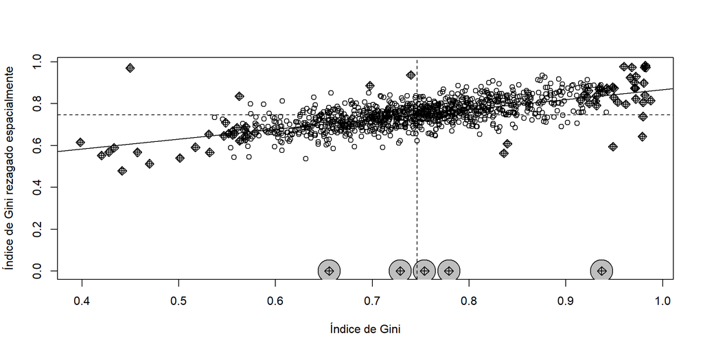

## Modelo SAR

**Tip**

$\mathbf{X}$: $X_1$: un índice asociado al uso adecuado del suelo rural, $X_2$: un índice de competitividad, $X_3$: un índice de productividad, $X_4$: el índice de fortaleza institucional, y $X_5$: la tasa de homicidios por cada 100.000 habitantes.

```r
HomSARAR <- lagsarlm(GINI~X1+X2+X3+X4+X5,
                     data=DataComplete,
                     listw =cont.listw,
                     zero.policy = T, )
summary(HomSARAR)
```

```
Call:lagsarlm(formula = GINI ~ X1 + X2 + X3 + X4 + X5, data = DataComplete,
    listw = cont.listw, zero.policy = T)

Residuals:
      Min        1Q    Median        3Q       Max
-0.386793 -0.044820  0.001196  0.044232  0.363880

Type: lag
Regions with no neighbours included:
 48 52 1056 1057 1064
Coefficients: (asymptotic standard errors)
              Estimate Std. Error z value  Pr(>|z|)
(Intercept) 3.1616e-01 2.1750e-02 14.5360 < 2.2e-16
X1          1.5794e-04 1.0652e-04  1.4828 0.1381207
X2          6.6176e-04 1.6934e-04  3.9079 9.311e-05
X3          2.3087e-03 2.2543e-04 10.2411 < 2.2e-16
X4          1.2595e-03 3.3620e-04  3.7464 0.0001794
X5          7.7680e-05 6.3971e-05  1.2143 0.2246350

Rho: 0.44054, LR test value: 268.94, p-value: < 2.22e-16
Asymptotic standard error: 0.026989
    z-value: 16.323, p-value: < 2.22e-16
Wald statistic: 266.44, p-value: < 2.22e-16

Log likelihood: 1250.187 for lag model
ML residual variance (sigma squared): 0.0054194, (sigma: 0.073616)
Number of observations: 1068
Number of parameters estimated: 8
AIC: -2484.4, (AIC for lm: -2217.4)
LM test for residual autocorrelation
test value: 62.39, p-value: 2.7756e-15
```

## Siguiente clase

- Análisis de los coeficientes de cada covariable $X_j$.
- Criterios de diagnóstico del modelo, residuales y AIC.
- Predicción de valores fuera de la muestra.
- Estimación robusta de $\rho$ con la metodología de Kelejian y Prucha (2010).

# Bloque 2: Plan Docente

**Curso**

Modelos Estadísticos y de Aprendizaje Automático para datos Espacio-Temporales

**Introducción**

- Qué es autocorrelación: valores cercanos tienden a ser similares
- Tipos:
  - Temporal: series de precios, temperatura diaria
  - Espacial: deforestación, crimen por vecindario
  - Espacio temporal: Combinación de las anteriores.
- Importancia en análisis de datos georreferenciados. Manejo de mapas en R, Python y GIS.

## Modelos estadísticos

**Espaciales**

- Estructuras de autocorrelación espacial.
- Modelos SAR y SEM: capturan dependencia entre ubicaciones
- Concepto de matriz de pesos espaciales (W)
- Interpretación: impactos directos e indirectos
- Aplicaciones: predicción de fenómenos geográficos y socioeconómicos

**Temporales (Recordatorio de Series de Tiempo)**

- Autoregresión temporal: persistencia en el tiempo. AR, MA, ARMA y extensiones
- Estructuras de autocorrelación temporal, ACF y PACF.

## Modelos estadísticos

**Espacio-temporales**

- Correlación espacial, regularización, validación espacial y temporal
- **SARAR temporal:** captura dependencia tanto en variable dependiente como en perturbaciones a través del tiempo y espacio
- **SAR heterocedástico para datos de panel:** maneja varianza no constante en observaciones espaciales y temporales
- **GEE espaciales y semiparamétricos:** para estructuras de correlación complejas

## Machine Learning

**Tip**

- **Métodos clásicos adaptados:**
  - **Random Forest espacio-temporal:** incorpora covariables espaciales y dependencias temporales
- **Avances en redes neuronales:**
  - **Convolutional LSTM y CNN para datos georreferenciados:** integran información espacial y temporal
  - **Spatio-Temporal Deep Learning:** combina redes recurrentes y convolucionales para predicción de series geoespaciales

## Evaluación del curso

**Evaluaciones presenciales**

- **Prueba 1 (20%)**
  - Evaluación computacional sobre conceptos básicos espaciales y temporales
  - Resolución de ejercicios con R o Python
- **Prueba 2 (20%)**
  - Evaluación computacional sobre modelos espacio-temporales y ML
  - Interpretación de resultados y análisis de impactos

**Proyecto**

- **Proyecto final (60%)**
  - Aplicación práctica a un dataset real.
  - Lectura de artículos científicos en el área
  - Combinar teoría de modelos clásicos con métodos de ML
  - Análisis reproducible, predicciones y visualización (mapas de riesgo)

## Bibliografía clave

- Anselin, L. (1988). *Spatial Econometrics: Methods and Models.*
- Cressie, N. (1993). *Statistics for Spatial Data.*
- Hastie, T., Tibshirani, R., & Friedman, J. (2009). *The Elements of Statistical Learning.*
- Guignard, F. (2022). *On Spatio-Temporal Data Modelling and Uncertainty Quantification Using Machine Learning and Information Theory*.
- Wickle, C. & Zammit-Mangion, A. (2023) *Statistical Deep Learning for Spatial and Spatiotemporal Data*

## Formación básica

**Fundamentación**

- **Básica y transversal**: Estadística descriptiva, probabilidad para ingeniería, ciencias y sociales.
- **Fundamentos teóricos**: Probabilidad y estadística en pregrado de estadística y matemáticas.
- **Estadística teórica y aplicada**: Análisis estadístico de datos espaciotemporales
- **Enfoque pedagógico**: Rigor teórico + aplicaciones prácticas; metodologías activas y proyectos interdisciplinarios.

**Soporte**

- He dictado clases en diferentes programas de pregrado en la **Universidad Nacional de Colombia**, la **Universitat de les Illes Balears** y otras instituciones, fortaleciendo tanto la formación básica como la avanzada en estadística.
- He acompañado la **dirección de trabajos de grado** en áreas de matemáticas, estadística e ingeniería

## Áreas avanzadas

**Estadística avanzada**

- **Diseño experimental** para programas de estadística y áreas afines (agronomía, biología, ingeniería).
- **Estadística experimental y validación de escalas** en maestría y especialización, con aplicaciones a problemáticas nacionales como Tuberculosis, seguridad y salud en el trabajo y enfermedades de transmisión sexual.
- **Aprendizaje de máquina y modelado en la nube**, orientado a grandes volúmenes de datos y procesos de predicción.
- Énfasis en el **desarrollo de competencias analíticas sólidas**, combinando teoría rigurosa con aplicaciones prácticas e interdisciplinarias.

**Soporte**

- He dictado cursos en **diversas maestrías** y programas de posgrado en estadística y áreas afines.
- He impartido formación especializada para **corporaciones bancarias** y otras instituciones del sector productivo.
- He trabajado como **consultor en el ICFES, en CALA y en otras entidades nacionales e internacionales**.

## Recursos didácticos

- Material actualizado y libre acceso. Plataformas digitales (GitHub) con códigos y ejemplos.
  - [Estadística para Farmacia](https://cruzalirio.github.io/Farmacia/)
  - [Aprendizaje de Máquina](https://madcentral.github.io/metodosestadisticos/)
  - [Estadística para Enfermería](https://github.com/Cruzalirio/Unal-Enfermeria-/tree/main)
  - [Aprendizaje de máquina](https://drive.google.com/drive/folders/1D2fYj_BEuGXC8m6qQNe56El5H6fx53i5?usp=sharing)
  - [Fundamentos de Estadística](https://drive.google.com/drive/folders/13pES47M5AGwdI2FzZL6GHYe5mmL-8yfn?usp=sharing)

  **Tip**
  - **Uso intensivo de software estadístico** para análisis reproducible y aprendizaje práctico.
  - **Resolución de problemas reales**, aplicando estadística a situaciones concretas de distintas disciplinas.
  - **Fomento de la interdisciplinariedad e innovación**, promoviendo proyectos que integren teoría, datos y aplicación.

## Adicionalmente

**Importante**

- Coordiné durante un año la **Maestría en Analítica de Datos de la Universidad Central**, siendo **uno de sus creadores**.
- He **asesorado varias tesis** en la Universidad como **estadístico**, apoyando investigación académica en distintas áreas.
- **Competencia multilingüe**, lo que permite enseñar a estudiantes de distintos países o en programas internacionales.
- **Flexibilidad docente**, adaptando contenidos y ejemplos según el idioma y contexto cultural.
- **Mayor alcance y visibilidad académica**, especialmente para cursos de posgrado o colaboraciones internacionales.
- He dirigido **tesis de maestría en áreas diversas** articulando investigación académica con problemáticas reales.

# Bloque 2: Plan Investigativo

## Tema y contexto

- Tema: Modelación espacio-temporal de la deforestación municipal en Colombia
- Enfoque: Estadístico robusto, econometría espacial y GAMLSS
- Contexto: fenómeno multicausal, necesidad de análisis a nivel municipal

  **Avances**
  - Trabajo teórico avanzado con articulos publicados y preprints en el área. Toloza-Delgado, Melo, y Cruz (2025), Azcarate-Romero et al. (2025)
  - Software Estadístico, con un paquete en R: [spatemR](https://cran.r-project.org/web/packages/spatemR/index.html)
  - Un preprint con pronóstico de datos faltantes espaciales Tobar et al. (2025).

## Preguntas de investigación

**Nota**

- ¿Cómo se distribuye espacial y temporalmente la deforestación?
- ¿Qué factores socioeconómicos e institucionales la explican?
- ¿Qué tan efectivos son los modelos clásicos frente a GSAR/GAMLSS?
- ¿Cómo manejar heterocedasticidad, no normalidad y correlación espacio-temporal?

**Avances**

- Un preprint de estadística espacio temporal en revisión Cruz, Romero, y Melo (2025).
- Una tesis de maestría dirigida sobre el tema en la Universidad Central, *Desarrollo de un modelo predictivo con técnicas de inteligencia artificial que permita la identificación de municipios en riesgo de deforestación mediante la incorporación de variables socioeconómicas espaciales.*

## Objetivo general

**Objetivo**

Desarrollar e implementar **modelos estadísticos espacio-temporales robustos** que permitan **evaluar, explicar y predecir la deforestación municipal** en Colombia, integrando metodologías avanzadas de econometría espacial y modelamiento estadístico.

1. Integración de fuentes de datos:
   - Cobertura boscosa anual (IDEAM), Factores de presión: agroindustria, cultivos ilícitos, vías
   - Variables socioeconómicas: población rural, minería, conflictos, Información climática y presupuestal (CHIRPS, DANE, SECOP)
2. Modelamiento espacio-temporal:
   - SAR y SEM clásicos, SAR heterocedástico (GAMLSS)
   - GSAR para conteos y proporciones no normales, Modelos semiparamétricos tipo GEE

## Validación, resultados y plan de trabajo

- Validación cruzada espacial y comparación de escenarios
- Resultados esperados:
  - Mapas de riesgo municipal
  - Predicciones con incertidumbre
  - Paquete en R y publicaciones científicas
- Plan de trabajo anual:
  - Año 1: Recolección y análisis de datos
  - Año 2: Desarrollo de modelos y validación
  - Año 3: Difusión, mapas de riesgo y transferencia tecnológica
- Pertinencia institucional: integración docencia-investigación y fortalecimiento de estadística aplicada

# Bloque 3: Proyección misional

## Contribución a los fines misionales

- **Contribuir a la unidad nacional y su vinculación internacional**
  - Mis proyectos sobre deforestación municipal generan conocimiento que puede ser aplicado en políticas públicas nacionales e integrarse en redes internacionales de investigación ambiental.
- **Crear y asimilar críticamente el conocimiento**
  - Desarrollo de modelos SAR, GAMLSS y GSAR para análisis espacial avanzado, generando nuevo conocimiento metodológico aplicable a problemas reales de Colombia.

## Contribución a los fines misionales

- **Formar profesionales e investigadores con conciencia crítica**
  - Integración de teoría estadística, programación y análisis reproducible en pregrado y posgrado.
  - Preparación de estudiantes para liderar investigaciones y proyectos de política ambiental.
- **Estudiar y enriquecer el patrimonio natural y contribuir a su conservación (Apoyo a la sociedad y al Estado)**
  - Análisis espacial de deforestación que permite identificar zonas críticas y generar mapas de riesgo para la toma de decisiones ambientales.

## Contribución a los fines misionales

- **Propender por el desarrollo personal y académico de la comunidad**
  - Uso de metodologías activas, software libre y recursos abiertos para fortalecer capacidades analíticas y de investigación en estudiantes.
  - Generación de herramientas estadísticas y mapas de riesgo que sirven para asesoría en políticas públicas y toma de decisiones en gestión ambiental.
- **Fomentar la interdisciplinariedad y la cooperación**
  - Vinculación de estudiantes y grupos de investigación con proyectos interinstitucionales y redes académicas internacionales en estadística aplicada y medio ambiente.

## Bibliografía

Azcarate-Romero, J. S., J. D. Toloza-Delgado, N. A. Cruz Gutierrez, y P. A. Mahecha. 2025. «Urban Spatial Analysis of the Profitability of Housing Rental in Bogotá». *International Journal of Housing Markets and Analysis*, agosto. https://doi.org/10.1108/ijhma-04-2025-0085.

Bivand, Roger, Giovanni Millo, y Gianfranco Piras. 2021b. «A Review of Software for Spatial Econometrics in R» 9. https://doi.org/10.3390/math9111276.

———. 2021a. «A Review of Software for Spatial Econometrics in R» 9. https://doi.org/10.3390/math9111276.

Cruz Gutierrez, Nelson Alirio, Oscar Orlando Melo, y Jurgen Toloza-Delgado. 2025. «Joint spatial modeling of mean and non-homogeneous variance combining semiparametric SAR and GAMLSS models for hedonic prices» 65: 100864. https://doi.org/10.1016/j.spasta.2024.100864.

Cruz, N. A., D. A. Romero, y O. O. Melo. 2025. «SAR models with specific spatial coefficients and heteroskedastic innovations». https://doi.org/10.48550/ARXIV.2502.15580.

Kelejian, Harry H., y Ingmar R. Prucha. 2010. «Specification and Estimation of Spatial Autoregressive Models with Autoregressive and Heteroskedastic Disturbances». *Journal of Econometrics* 157 (1): 53-67. https://doi.org/10.1016/j.jeconom.2009.10.025.

Lee, Lung-Fei. 2004. «Asymptotic Distributions of Quasi-Maximum Likelihood Estimators for Spatial Autoregressive Models». *Econometrica* 72 (6): 1899-1925. https://doi.org/10.1111/j.1468-0262.2004.00558.x.

*Theory of Point Estimation*. 1998. Springer-Verlag. https://doi.org/10.1007/b98854.

Tobar, A., A. Mir, R. Alberich, I. Garcia, M. Miró, y NA. Cruz. 2025. «Spatial disaggregation of time series». https://doi.org/10.48550/ARXIV.2509.04065.

Toloza-Delgado, J. D., O. O. Melo, y N. A. Cruz. 2025. «Joint Spatial Modeling of Mean and Non-Homogeneous Variance Combining Semiparametric SAR and GAMLSS Models for Hedonic Prices». *Spatial Statistics* 65 (marzo): 100864. https://doi.org/10.1016/j.spasta.2024.100864.